# Truco de magia (transiciones)

[Guillermo Montero-Melis](https://www.mpi.nl/people/montero-melis-guillermo)

15/04/2020

```r
## Definir las funciones clave:
# Rellenar cada fila de la matriz de transiciones
fill_row <- function(i, j, n) {
  mat_row <- rep(0, times = n^2)
  counter <- 0
  for (col_i in seq.int(n)) {
    for (col_j in seq.int(n)) {
      counter <- counter + 1
      if (
        (i == col_i & (j == col_j - 1 | j == col_j + 1)) |
        (j == col_j & (i == col_i - 1 | i == col_i + 1))
      ) {
        mat_row[counter] <- 1
      }
    }
  }
  mat_row
}
# Construir la matriz de transiciones para un tablero n x n
make_transition_matrix <- function (n) {
  m <- matrix(NA, nrow = n^2, ncol = n^2)
  row_counter <- 1
  for (i in seq.int(n)) {
    for (j in seq.int(n)) {
      m[row_counter, ] <- fill_row(i,j,n)
      row_counter <- row_counter + 1
    }
  }
  mynames <- paste(
    rep(seq.int(n), each = n),
    rep(seq.int(n), times = n),
    sep = "-"
    )
  rownames(m) <- mynames
  colnames(m) <- mynames
  m
}
# Obtener matriz de transiciones tras borrar celdas
delete_cells <- function (cells_out, m) {
  (cell_index <- ! colnames(m) %in% cells_out)
  m[cell_index, cell_index]
}
# Obtener casillas a las que te puedes mover a partir de casillas (start_cells)
move_1_step <- function (start_cells, m) {
  target_cells <- matrix(nrow = nrow(m), ncol = length(start_cells))
  counter <- 1
  for (cell in start_cells) {
    target <- m[, colnames(m) == cell]
    target_cells[, counter] <- target
    counter <- counter + 1
  }
  targets <- apply(target_cells, 1, function(x) as.numeric(sum(x) != 0))
  names(targets) <- colnames(m)
  targets
}
# A qué casillas puedes llegar tras n pasos saliendo de start_cells
move_n_steps <- function(start_cells, steps, m) {
  end_cells <- move_1_step(start_cells, m)
  k <- 1
  while (k < steps) {
    curr_cells <- names(end_cells)[end_cells == 1]
    end_cells <- move_1_step(curr_cells, m)
    k <- k + 1
  }
  end_cells
}
```

```r
## Definir algunas funciones adicionales para visualizar etc.:
# Sustituye valores en el vector de posiciones, preservando los NA:
update_cells <- function (cells_old, cells_new) {
  cells_old[names(cells_old) %in% names(cells_new)] <- cells_new
  cells_old
}
# pintar posiciones en el tablero:
paint_cells <- function(cells, board_dim = 4) {
  if (board_dim^2 != length(cells)) stop("Wrong dimension or cell vector!")
  df <- expand.grid(column = 1:board_dim, row = 1:board_dim)
  df$row <- factor(df$row, levels = as.character(board_dim : 1))  # order rows
  df$pos <- factor(cells)
  df
  ggplot(df, aes(x = column, y = row, fill = pos, colour = "black")) +
    geom_raster() +
    labs(fill = NULL)
}
# Dibujar matriz de transiciones
plot_matrix <- function(m) {
  mynames <- rownames(m)
  mynames <- mynames[length(mynames):1]
  rownames(m) <- mynames
  colnames(m) <- mynames
  heatmap(m[,nrow(m):1],symm = TRUE, Rowv = NA, Colv = NA)
}
```

```r
# variables globales
fig_hei <- 2
fig_wid <- 3
```

# 1 ¿Por qué funciona el truco?

Lo mejor es resolverlo visualmente.

## 1.1 El tablero

El tablero inicial consta de 4 x 4 casillas dispuestas en un cuadrado. Las podemos llamar como queramos. En el juego las llaman “jardín”, “baño”, “habitación”, etc.

Para nosotros será más práctico referirnos a cada casilla por su índice de fila (*i*) y su índice de columna (*j*). De esta manera:

```r
mynames <- paste(
  rep(seq.int(4), each = 4),
  rep(seq.int(4), times = 4),
  sep = "-"
  )
matrix(mynames, ncol = 4, byrow = TRUE)
```

```
##      [,1]  [,2]  [,3]  [,4]
## [1,] "1-1" "1-2" "1-3" "1-4"
## [2,] "2-1" "2-2" "2-3" "2-4"
## [3,] "3-1" "3-2" "3-3" "3-4"
## [4,] "4-1" "4-2" "4-3" "4-4"
```

```r
m4 <- make_transition_matrix(4)
```

Y visualmente, para marcar a qué casillas nos podemos mover, podemos utilizar una representación del tablero. Por ejemplo, así marcamos que salimos de la casilla 3-1, como nos indica el mago:

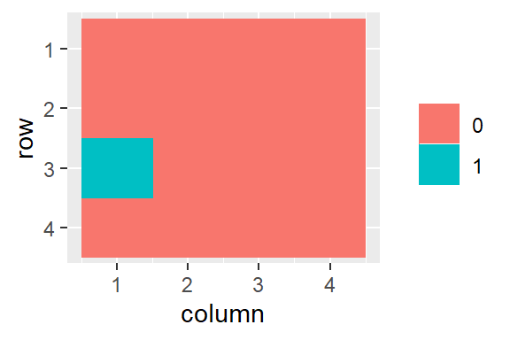

```r
cell31 <- rep(0, 16)
cell31[9] <- 1
paint_cells(cell31)
```

Leyenda de colores:

- Una casilla azul (=1) indica que estamos o podríamos estar en ella
- Una casilla roja (=0) es una en la que no podemos estar

## 1.2 El truco paso a paso

### 1.2.1 Primera fase

En la primera fase nos podemos mover libremente por el tablero, siguiendo las reglas de no movernos más que una casilla a los lados, arriba o abajo por cada paso. Tenemos que dar cinco pasos.

Puesto que comenzamos en la casilla 3-1, en el primer paso nos podemos mover a las siguientes casillas:

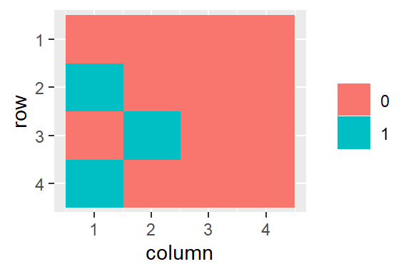

```r
move_n_steps(start_cells = "3-1", steps = 1, m = m4) %>%
  paint_cells()
```

Puesto que podemos acabar en cualquiera de ellas, en el 2º paso podemos acabar en cualquiera de las siguientes:

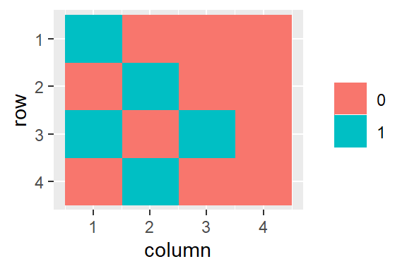

```r
move_n_steps("3-1", 2, m4) %>%
  paint_cells()
```

En el tercer paso:

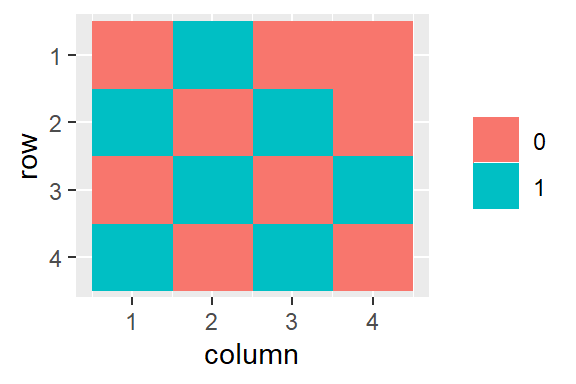

```r
move_n_steps("3-1", 3, m4) %>%
  paint_cells()
```

Cuarto:

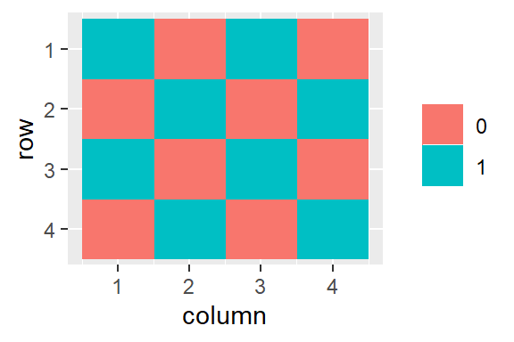

```r
move_n_steps("3-1", 4, m4) %>%
  paint_cells()
```

Y finalmente, al cabo de cinco pasos, estas son las casillas *posibles*, es decir aquellas a las que podemos llegar siguiendo cualquiera de los caminos lícitos:

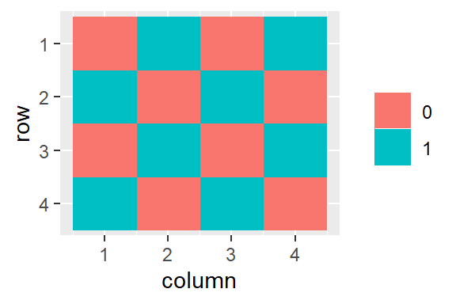

```r
move_n_steps("3-1", 5, m4) %>%
  paint_cells()
```

Llegados a este punto, el mago elimina algunas de las casillas. Muy astuto, solo elimina algunas de aquellas a las que de todas formas no podíamos haber llegado. El tablero se queda así:

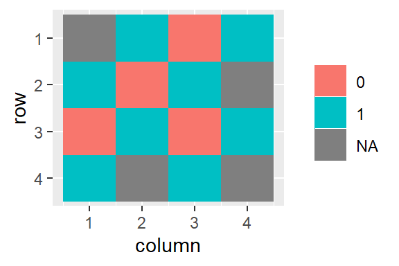

```r
fase1_fin <- move_n_steps("3-1", 5, m4)
fase1_fin[c(1, 8, 14, 16)] <- NA
paint_cells(fase1_fin)
```

*NA* marca una casilla anulada.

### 1.2.2 Segunda fase

```r
# Nueva matriz de transiciones
m4_2 <- delete_cells(c("1-1", "2-4", "4-2", "4-4"), m4)
```

En ese nuevo tablero nos hemos de mover tres pasos.

Aquí podemos llegar en un paso.

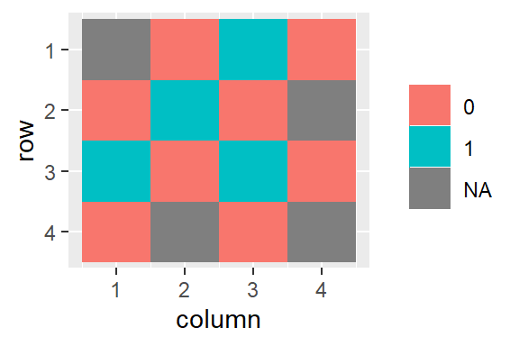

```r
start_cells_f2 <- names(fase1_fin[fase1_fin == 1 & !is.na(fase1_fin)])
fase2 <- move_n_steps(start_cells_f2, 1, m4_2)
update_cells(fase1_fin, fase2) %>%
  paint_cells()
```

En dos:

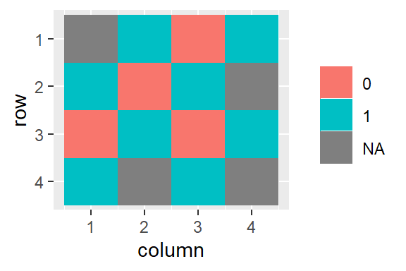

```r
fase2 <- move_n_steps(start_cells_f2, 2, m4_2)
update_cells(fase1_fin, fase2) %>%
  paint_cells()
```

Y en tres:

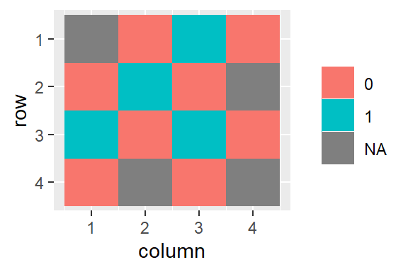

```r
fase2 <- move_n_steps(start_cells_f2, 3, m4_2)
update_cells(fase1_fin, fase2) %>%
  paint_cells()
```

Al final de la fase 2, el mago elimina otras cinco casillas. Las siguientes:

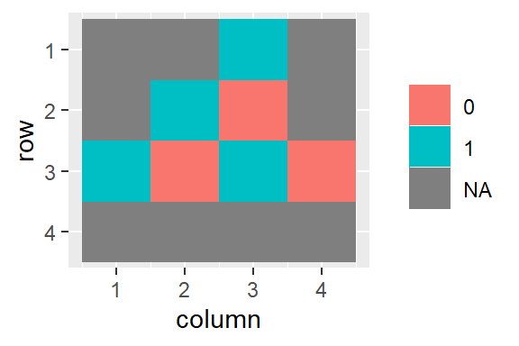

```r
fase2_fin <- update_cells(fase1_fin, fase2)
fase2_fin[c(2, 4, 5, 13, 15)] <- NA
paint_cells(fase2_fin)
```

Hábilmente, ninguna de las eliminadas está entre las que podríamos estar.

### 1.2.3 Tercera fase

```r
# Nueva matriz de transiciones
m4_3 <- delete_cells(c("1-2", "1-4", "2-1", "4-1", "4-3"), m4_2)
```

En este nuevo tablero, nos hemos de mover otros tres pasos. En el primero podríamos llegar a:

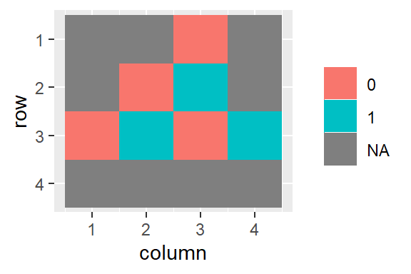

```r
start_cells_f3 <- names(fase2_fin[fase2_fin == 1 & !is.na(fase2_fin)])
fase3 <- move_n_steps(start_cells_f3, 1, m4_3)
update_cells(fase2_fin, fase3) %>%
  paint_cells()
```

En dos:

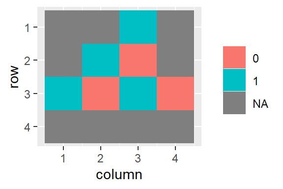

```r
fase3 <- move_n_steps(start_cells_f3, 2, m4_3)
update_cells(fase2_fin, fase3) %>%
  paint_cells()
```

Y en tres:

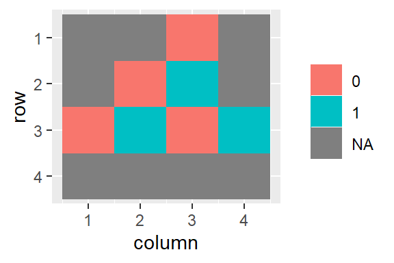

```r
fase3 <- move_n_steps(start_cells_f3, 3, m4_3)
update_cells(fase2_fin, fase3) %>%
  paint_cells()
```

Ahora ya le vemos el plumero al mago. En este momento nos elimina todas las casillas en las que no podríamos estar, menos la 3-3 (el salón):

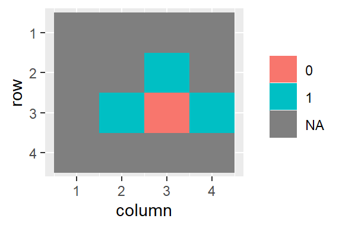

```r
fase3_fin <- update_cells(fase2_fin, fase3)
fase3_fin[c(3, 6, 9)] <- NA
paint_cells(fase3_fin)
```

Ahora es fácil ver cómo puede rematar. Estemos en la casilla que estemos, ¡en el siguiente paso **solo podemos acabar en la casilla 3-3, el salón**!

### 1.2.4 Grand finale

Chachán…

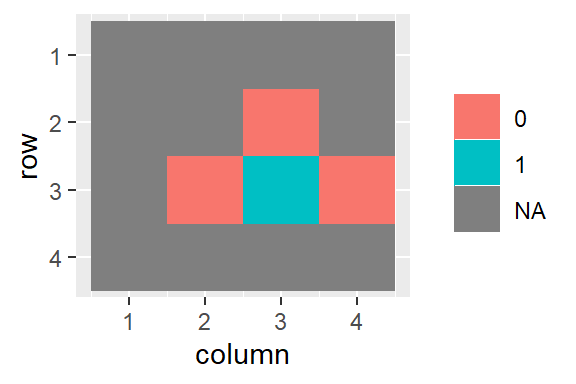

```r
# Nueva matriz de transiciones
m4_4 <- delete_cells(c("1-3", "2-2", "3-1"), m4_3)
start_cells_f4 <- names(fase3_fin[fase3_fin == 1 & !is.na(fase3_fin)])
fase4 <- move_n_steps(start_cells_f4, 1, m4_4)
update_cells(fase3_fin, fase4) %>%
  paint_cells()
```

¡EN EL SALÓN TODOS!

# 2 ¿Qué ocurre tras bastidores?

## 2.1 Movimientos en el tablero

Nos referimos a cada casilla del tablero por su índice de fila (*i*) y su índice de columna (*j*). De esta manera:

```r
mynames <- paste(
  rep(seq.int(4), each = 4),
  rep(seq.int(4), times = 4),
  sep = "-"
  )
matrix(mynames, ncol = 4, byrow = TRUE)
```

```
##      [,1]  [,2]  [,3]  [,4]
## [1,] "1-1" "1-2" "1-3" "1-4"
## [2,] "2-1" "2-2" "2-3" "2-4"
## [3,] "3-1" "3-2" "3-3" "3-4"
## [4,] "4-1" "4-2" "4-3" "4-4"
```

Las reglas de juego son que desde cada casilla podemos dar un paso a un lado o hacia arriba o abajo, siempre que haya casillas claro. Así que desde la casilla “3-1”, por ejemplo, nos podemos mover a la “2-1”, “3-2” o “4-1”. Algo similar podríamos hacer para cada casilla, obteniendo así una lista de las casillas a las que podemos llegar desde una casilla cualquiera. Eso definiría cómo nos podemos mover dentro de ese tablero estemos donde estemos y dando un solo paso.

¿Cuál es la mejor manera de expresar esta información?

## 2.2 Matriz de transiciones: un ejemplo más sencillo

La matriz de transiciones define los movimientos lícitos en nuestro tablero

Empecemos con un ejemplo más sencillo. Imaginemos un tablero de dimensiones 2 x 2:

```r
mynames2 <- paste(
  rep(seq.int(2), each = 2),
  rep(seq.int(2), times = 2),
  sep = "-"
  )
matrix(mynames2, ncol = 2, byrow = TRUE)
```

```
##      [,1]  [,2]
## [1,] "1-1" "1-2"
## [2,] "2-1" "2-2"
```

Podríamos haber llamado las casillas de otra forma (como en en el truco de magia):

```r
matrix(c("entrada", "salón", "baño", "dormitorio"), ncol = 2, byrow = TRUE)
```

```
##      [,1]      [,2]
## [1,] "entrada" "salón"
## [2,] "baño"    "dormitorio"
```

Pero es mejor quedarnos con los índices:

```r
matrix(mynames2, ncol = 2, byrow = TRUE)
```

```
##      [,1]  [,2]
## [1,] "1-1" "1-2"
## [2,] "2-1" "2-2"
```

La matriz de transiciones tiene la siguiente forma:

```r
make_transition_matrix(2)
```

```
##     1-1 1-2 2-1 2-2
## 1-1   0   1   1   0
## 1-2   1   0   0   1
## 2-1   1   0   0   1
## 2-2   0   1   1   0
```

¿Cómo se lee esta matriz? Fila por fila. Comienzas en la primera fila de la matriz, que se llama “1-1”. Eso significa que estamos en esa casilla del tablero (“1-1” o “entrada”).

Ahora vas leyendo los valores para cada columna:

- La primera columna se llama “1-1” y el valor es 0. Eso significa que desde la casilla “1-1” *no* puedes moverte a la casilla “1-1”. Esas eran las reglas.
- 2ª columna: “1-2”. Valor en la celda 1. Significa que te puedes mover a esa casilla. Correcto. De la entrada puedes ir al salón.
- 3ª columna: “2-1”, valor es 1. Bien, de la entrada también puedes ir al baño.
- 4ª columna: “2-2” y el valor es 0 porque en un paso no puedes llegar a ella desde la casilla “1-1”

Lo mismo podemos hacer para la 2ª fila. Esta nos indicará a qué casillas sí nos podemos mover si estamos en la “1-2” (tendrán un 1 en la columna correspondiente) y a cuáles no (tendrán un 0).

*Observaciones*:

- En este ejemplo más sencillo, el tablero tenía dimensiones $2 \times 2$; constaba de 4 casillas. Las dimensiones de nuestra matriz de transiciones, en cambio, eran mayores: era $4 \times 4$ y constaba de 16 casillas.
- La mayor dimensión de la matriz de transición (el cuadrado de la del tablero) se debe a que a cada casilla en el tablero le corresponde una fila y una columna en el tablero.

## 2.3 Matriz de transiciones para el tablero original

He aquí la matriz de transiciones para el tablero del truco de magia original. Como el tablero tiene dimensiones $4 \times 4$ (16 casillas), las dimensiones de nuestra matriz de transiciones son $16 \times 16$ (256 casillas).

```r
m4
```

```
##     1-1 1-2 1-3 1-4 2-1 2-2 2-3 2-4 3-1 3-2 3-3 3-4 4-1 4-2 4-3 4-4
## 1-1   0   1   0   0   1   0   0   0   0   0   0   0   0   0   0   0
## 1-2   1   0   1   0   0   1   0   0   0   0   0   0   0   0   0   0
## 1-3   0   1   0   1   0   0   1   0   0   0   0   0   0   0   0   0
## 1-4   0   0   1   0   0   0   0   1   0   0   0   0   0   0   0   0
## 2-1   1   0   0   0   0   1   0   0   1   0   0   0   0   0   0   0
## 2-2   0   1   0   0   1   0   1   0   0   1   0   0   0   0   0   0
## 2-3   0   0   1   0   0   1   0   1   0   0   1   0   0   0   0   0
## 2-4   0   0   0   1   0   0   1   0   0   0   0   1   0   0   0   0
## 3-1   0   0   0   0   1   0   0   0   0   1   0   0   1   0   0   0
## 3-2   0   0   0   0   0   1   0   0   1   0   1   0   0   1   0   0
## 3-3   0   0   0   0   0   0   1   0   0   1   0   1   0   0   1   0
## 3-4   0   0   0   0   0   0   0   1   0   0   1   0   0   0   0   1
## 4-1   0   0   0   0   0   0   0   0   1   0   0   0   0   1   0   0
## 4-2   0   0   0   0   0   0   0   0   0   1   0   0   1   0   1   0
## 4-3   0   0   0   0   0   0   0   0   0   0   1   0   0   1   0   1
## 4-4   0   0   0   0   0   0   0   0   0   0   0   1   0   0   1   0
```

Aunque es mayor que la del ejemplo más sencillo, la manera de leer la información en ella es igual que arriba. Lo puedes verificar eligiendo una casilla en el tablero (p.ej. la “1-1”), yendo a la fila correspondiente de la matriz (la 1ª fila) y verificando que aquellas casillas a las que te puedes mover (es decir, las columnas correspondientes) tienen un 1. El resto de las entradas en esa fila deberían ser ceros.

*Observaciones*:

- La diagonal solo contiene ceros. Eso se debe a que cuando estás en una casilla siempre te tienes que mover a una contigua, no puedes dar un paso y quedarte en la misma.
- La matriz en nuestro caso es simétrica con respecto a la diagonal porque si de una casilla $x$ puedes moverte a una casilla $y$, también puedes moverte de $y$ a $x$.

## 2.4 Matrices con colores

Como las matrices de transiciones solo tienen unos y ceros, también se pueden representar con colores, lo cual hace resaltar un poco más su forma simétrica y los patrones que siguen. También es más bonito.

### 2.4.1 Matriz para el tablero $2 \times 2$

Primero la matriz numérica, luego la imagen:

```r
make_transition_matrix(2)
```

```
##     1-1 1-2 2-1 2-2
## 1-1   0   1   1   0
## 1-2   1   0   0   1
## 2-1   1   0   0   1
## 2-2   0   1   1   0
```

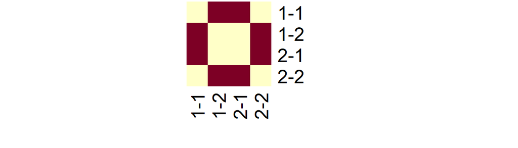

```r
plot_matrix(make_transition_matrix(2))
```

### 2.4.2 Matriz para el tablero $4 \times 4$

Esta es la imagen de la matriz 4x4:

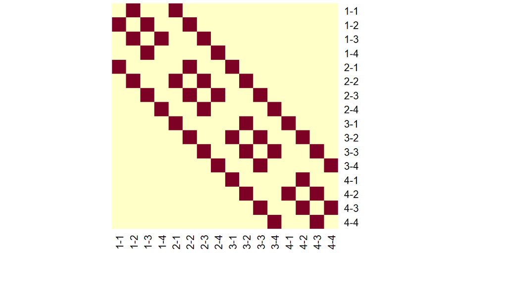

```r
plot_matrix(m4)
```

### 2.4.3 Matriz para el tablero $3 \times 3$ y $7 \times 7$

Lo mismo podemos obtener para un hipotético tablero de $3 \times 3$ casillas:

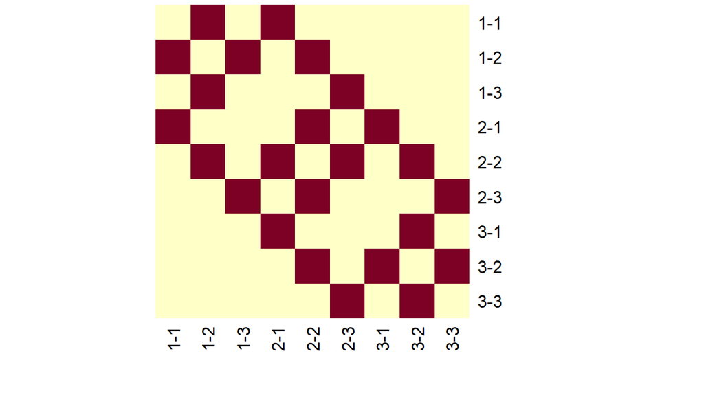

```r
# make_transition_matrix(3)
plot_matrix(make_transition_matrix(3))
```

O para una $7 \times 7$, por pura curiosidad:

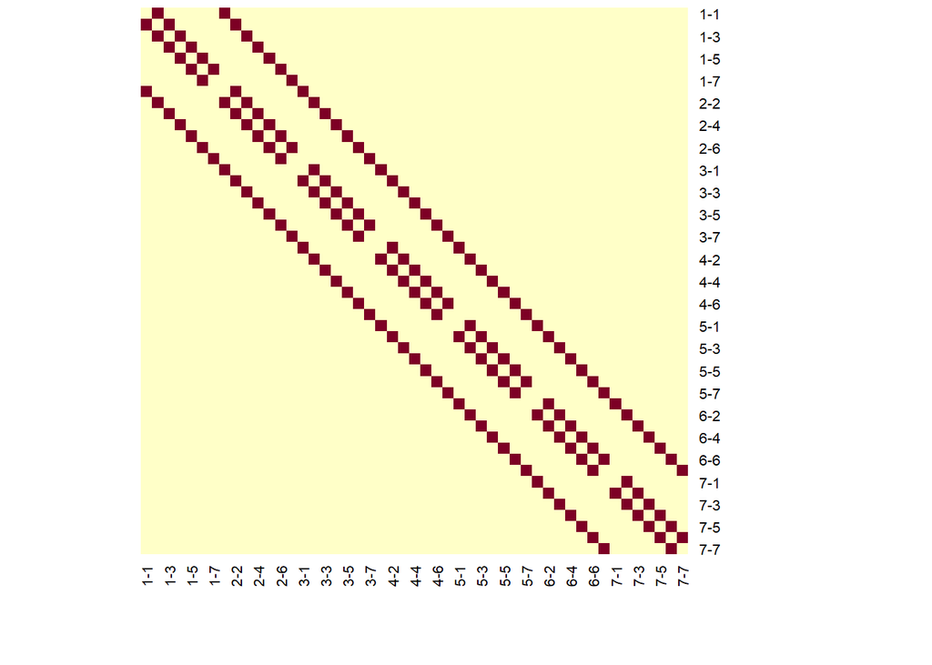

```r
# make_transition_matrix(7)
plot_matrix(make_transition_matrix(7))
```

## 2.5 ¿Adónde podemos llegar en n pasos?

La matriz de transiciones nos indica adónde nos podemos mover en cada paso. Para cada casilla (origen) nos dice si cualquier otra casilla es un destino lícito o no en el siguiente paso. Ahora bien, lo que nos interesa saber es adónde podemos llegar dando *más* de un paso. Eso es fácil una vez que tenemos la matriz de transiciones.

Con la función `move_n_steps()`, solo tenemos que indicar en qué casillas comenzamos (`start_cells`), cuántos pasos damos (`steps`) y en qué matriz nos movemos (`m`).

Por ejemplo, el mago nos dice que comenzamos en la casilla 3-1 y damos cinco pasos. Llamamos a la función con los parámetros correspondientes:

```r
move_n_steps(start_cells = "3-1", steps = 5, m = m4)
```

```
## 1-1 1-2 1-3 1-4 2-1 2-2 2-3 2-4 3-1 3-2 3-3 3-4 4-1 4-2 4-3 4-4
##   0   1   0   1   1   0   1   0   0   1   0   1   1   0   1   0
```

El resultado es un vector con 16 valores, uno para cada casilla del tablero. Los 1 y 0 nos dicen si, saliendo de la casilla 3-1 y dando 5 pasos lícitos, podríamos llegar a cada una de ellas o no.

Este vector es el que representábamos en forma de tablero en la primera parte:

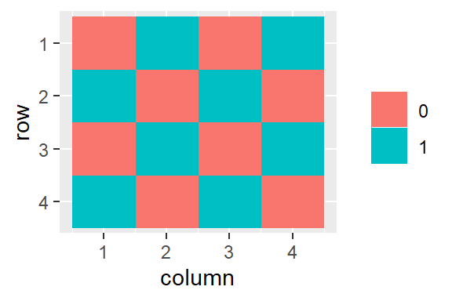

```r
paint_cells(move_n_steps("3-1", 5, m4))
```

## 2.6 Quitar casillas es simplificar la matriz de transiciones

Cuando el mago elimina casillas, lo único que está haciendo es quitar, para cada casilla eliminada, la fila y columna correspondientes de la matriz de transiciones. Así, tras la primera fase (una vez que hemos dado los cinco primeros pasos), quita cuatro casillas.

La matriz de transiciones pasa de ser esta:

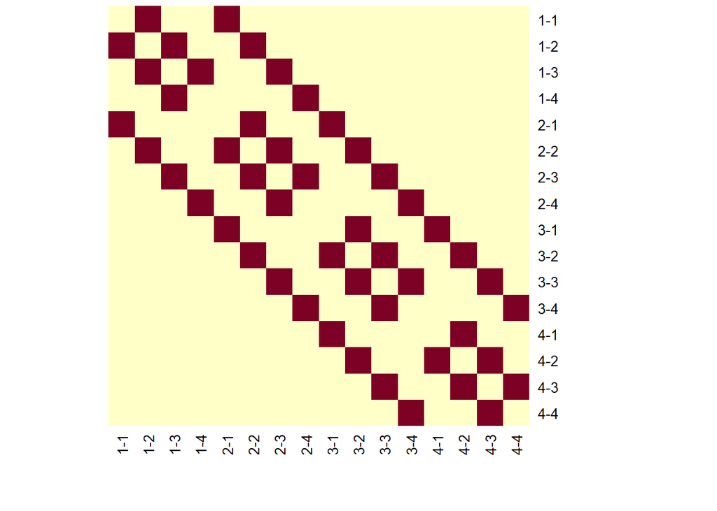

```r
plot_matrix(m4)
```

A ser esta:

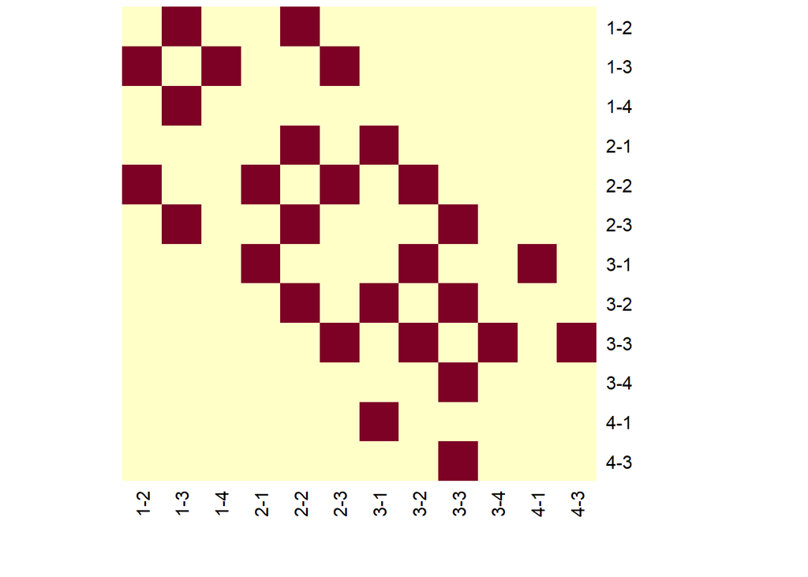

```r
# Nueva matriz de transiciones
m4_2 <- delete_cells(c("1-1", "2-4", "4-2", "4-4"), m4)
plot_matrix(m4_2)
```

Eso es todo lo que hace falta. Ahora ya podemos seguir el truco. Esta nueva matriz de transiciones corresponde a un tablero nuevo, una simplificación del original pero que no altera las reglas de movimiento. Por eso las funciones siguen funcionando.

Por ejemplo, saliendo de la casilla 3-1 en este nuevo tablero y dando dos pasos, podríamos llegar a las siguientes casillas:

```r
move_n_steps("3-1", 2, m4_2)
```

```
## 1-2 1-3 1-4 2-1 2-2 2-3 3-1 3-2 3-3 3-4 4-1 4-3
##   0   0   0   0   1   0   1   0   1   0   0   0
```

Con estos elementos ya tenemos todo lo que hace falta para resolver el problema para este tablero u otros más grandes.